# Práctica 1 Sistemas Inteligentes para la Gestión en la Empresa

Fernando Roldán Zafra

# Introducción

En esta primera práctica de Sistemas Inteligentes para la Gestión de la Empresa se va a analizar un problema que hoy en día cobra bastante relevancia. Y es que se trata de clasificar una serie de transacciones online en fraudulentas o no fraudulentas. Este problema, debido a la cantidad de transacciones financieras que se realizan hoy en día es de mucha relevancia y es que conocer que transacciones son legitimas o no pueden acarrear perdidas de grandes cantidades de dinero. Por lo tanto, en el presente trabajo aplicaremos diversas técnicas de análisis de datos para entrenar un modelo de clasificación que nos permita acercarnos lo más posible a la realidad.

Los datos que utilizaremos están recogidos en la plataforma *Kaggle* [1]. Estos datos pertenecen a la competición *IEEE-CIS Fraud Detection* [2]. Sin nada más que aclarar, empezamos por la descripción de los datos que tenemos para trabajar.

# Descripción del Dataset

Antes de realizar ningún tipo de técnica para la solución como tal del problema deberemos estudiar que datos tenemos y que forma tienen. Y es que no podremos realizar un análisis de calidad si no conocemos con que materia prima trabajamos.

```r
#Cargamos los paquetes
library(plyr)
library(caret)
library(funModeling)
library(dplyr)
```

```r
library(ggplot2)
library(tidyverse)
library(rpart)

# Cargamos los datos de un fichero en formato csv
train_raw <- read.csv("./train_innerjoin.csv", sep=",",  na = c('NA', 'n/a', '', ' '))
test_raw <- read.csv("./test_innerjoin.csv", sep=",",  na = c('NA', 'n/a', '', ' '))
# Mostramos los nombres de las columnas
length(train_raw)
```

```
## [1] 434
```

Como se puede ver, tenemos una gran cantidad de información a nuestra disposición. Sin embargo, muchas de estas columnas o atributos no son fácilmente interpretables y es que no se ofrece una descripción clara de algunos de ellos. Sin embargo, con estos atributos deberemos de ser capaces de obtener la clasificación buscada.

# Exploración

En esta sección vamos a ver que forma tienen los datos. De esta forma, en secciones posteriores podremos preprocesar dichos datos y adaptarlos a nuestras necesidades.

Primero representaremos 3 variables que a priori pueden ser interesantes, estas son *isFraud*, *ProductCD* y *DeviceType*. Estas pueden resultar interesantes, ya que son variables categóricas y nos interesa saber si hay desbalanceo en las variables.

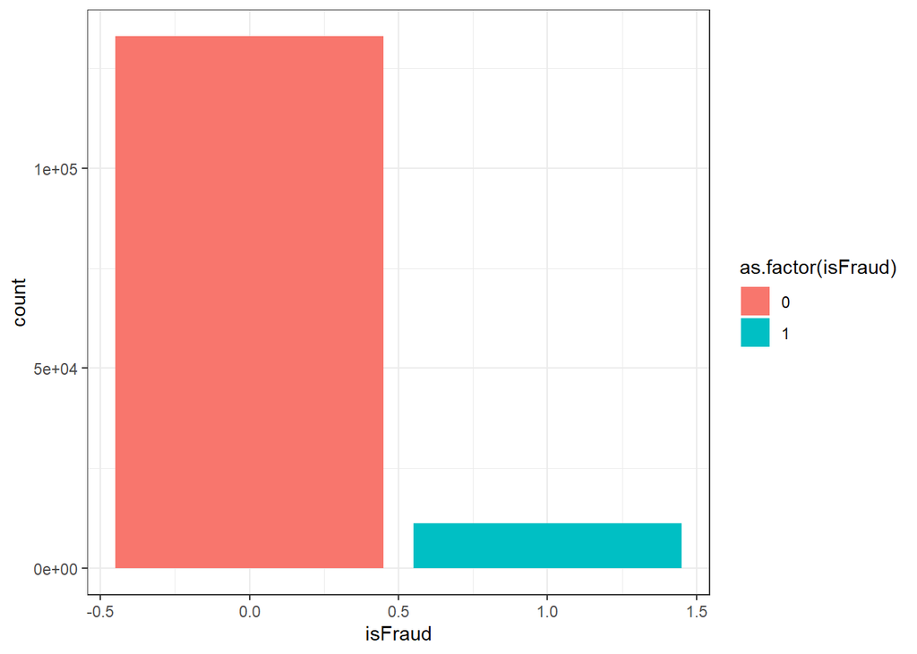

```r
#Graficas de valores categóricos
#IsFraud
ggplot(train_raw, aes(x=isFraud,fill=as.factor(isFraud))) + geom_bar() + theme_bw()
```

```r
table(train_raw$isFraud)
```

```
##
##      0      1
## 132915  11318
```

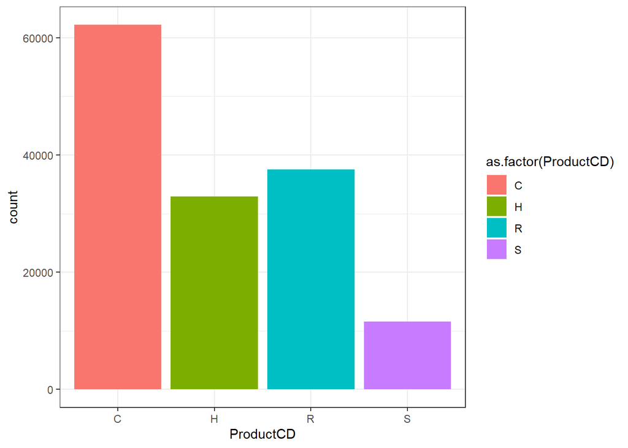

```r
#Porcentaje de aparicion de fraude
#prop.table(table(train_raw$isFraud))

#ProductCD
ggplot(train_raw, aes(x=ProductCD,fill=as.factor(ProductCD))) + geom_bar() + theme_bw()
```

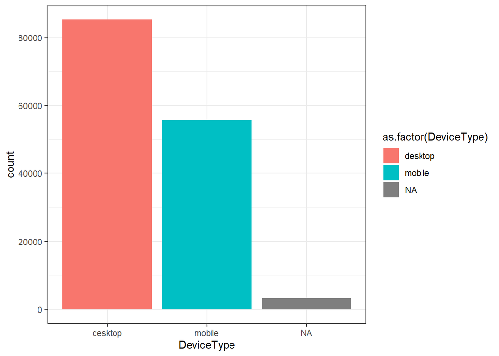

```r
#Devicetype
ggplot(train_raw, aes(x=DeviceType,fill=as.factor(DeviceType))) + geom_bar() + theme_bw()
```

Como se puede ver los datos están tremendamente desbalanceados, ya que la mayor parte de los datos pertenecen a casos de transacciones no fraudulentas. Más concretamente, el 92% de los datos son de transacciones no fraudulentas. Ademas de esto, podemos ver que en lo referente al código de los productos que estos están más balanceados. Aun así el significado de cada uno de estos no está claro, por lo que es difícilmente interpretable. Por último, podemos ver que la mayor parte de las transacciones se han realizado en un escritorio aunque no podemos despreciar la proporción de transacciones en móvil.

Veamos ahora la relación que tienen la cantidad de la transacción, el tipo de producto y el tipo de dispositivo con la posibilidad de que una transacción sea fraudulenta

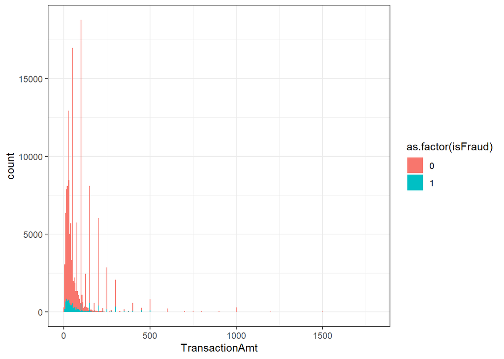

```r
#Visualización de Fraude por cantidad
ggplot(train_raw, aes(x=TransactionAmt, fill=as.factor(isFraud))) + theme_bw() +
  geom_histogram(binwidth=5)
```

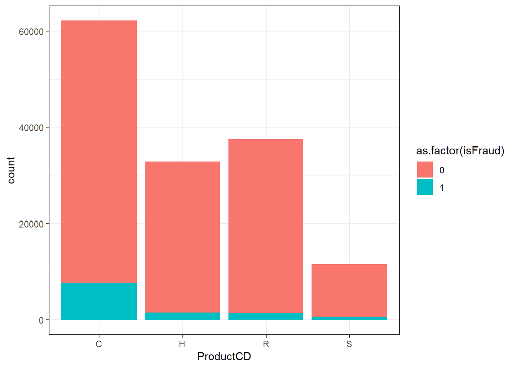

```r
#Visualización de Fraude por producto
ggplot(train_raw, aes(x=ProductCD,fill=as.factor(isFraud))) + geom_bar() + theme_bw()
```

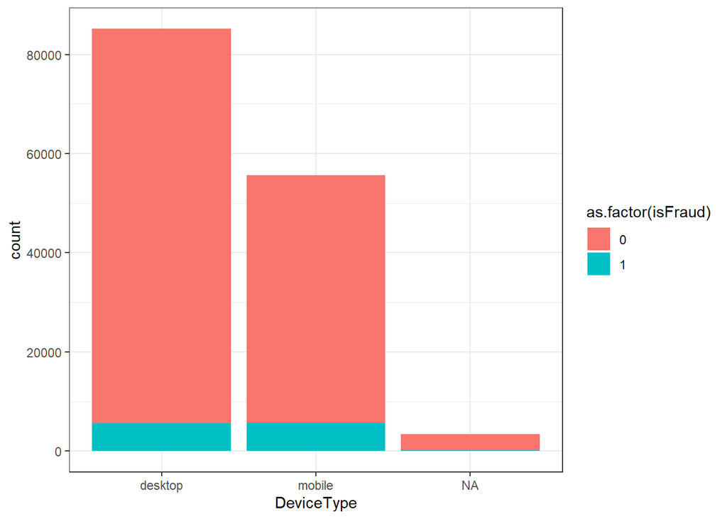

```r
#Visualización de Fraude por tipo de dispositivo
ggplot(train_raw, aes(x=DeviceType,fill=as.factor(isFraud))) + geom_bar() + theme_bw()
```

Por otro lado, otro aspecto interesante a analizar es ver los valores perdidos y que cantidad de ellos hay en nuestro dataset. El método utilizado está sacado de [3]

```r
#Valores perdidos
#Buscamos todas las columnas con valores perdidos
missing_train <- colSums(is.na(train_raw))[colSums(is.na(train_raw)) > 0] %>% sort(decreasing=T)
#Mostramos como salida el numero de columnas con valores perdidos
paste(length(missing_train), 'columas de', ncol(train_raw), 'tienen valores perdidos en train')
```

```
## [1] "412 columas de 434 tienen valores perdidos en train"
```

```r
#Calculamos el porcentaje de valores perdidos para estas columnas y lo redondeamos quedandonos con las dos primeras cifras decimales
missing_train_percentage <- round(missing_train/nrow(train_raw), 2)
#Mostramos los porcentajes mayores que 0.5
missing_train_percentage[missing_train_percentage > .5] %>% t
```

```
##      dist1 D11 M1 M2 M3 M5 M6 M7 M8 M9 V1 V2 V3 V4 V5 V6 V7 V8 V9 V10 V11
## [1,]     1   1  1  1  1  1  1  1  1  1  1  1  1  1  1  1  1  1  1   1   1
##      id_24 id_25 id_07 id_08 id_21 id_26 id_22 id_23 id_27  D3   D2   D5
## [1,]  0.97  0.96  0.96  0.96  0.96  0.96  0.96  0.96  0.96 0.8 0.78 0.77
##        D7 dist2 id_18  D12   M4  D13  D14  V35  V36  V37  V38  V39  V40
## [1,] 0.75  0.74  0.69 0.59 0.58 0.57 0.57 0.55 0.55 0.55 0.55 0.55 0.55
##       V41  V42  V43  V44  V45  V46  V47  V48  V49  V50  V51  V52   D4
## [1,] 0.55 0.55 0.55 0.55 0.55 0.55 0.55 0.55 0.55 0.55 0.55 0.55 0.55
##      id_03 id_04   D6  V53  V54  V55  V56  V57  V58  V59  V60  V61  V62
## [1,]  0.54  0.54 0.53 0.53 0.53 0.53 0.53 0.53 0.53 0.53 0.53 0.53 0.53
##       V63  V64  V65  V66  V67  V68  V69  V70  V71  V72  V73  V74  V75  V76
## [1,] 0.53 0.53 0.53 0.53 0.53 0.53 0.53 0.53 0.53 0.53 0.53 0.53 0.53 0.53
##       V77  V78  V79  V80  V81  V82  V83  V84  V85  V86  V87  V88  V89  V90
## [1,] 0.53 0.53 0.53 0.53 0.53 0.53 0.53 0.53 0.53 0.53 0.53 0.53 0.53 0.53
##       V91  V92  V93  V94  D15  V12  V13  V14  V15  V16  V17  V18  V19  V20
## [1,] 0.53 0.53 0.53 0.53 0.53 0.52 0.52 0.52 0.52 0.52 0.52 0.52 0.52 0.52
##       V21  V22  V23  V24  V25  V26  V27  V28  V29  V30  V31  V32  V33  V34
## [1,] 0.52 0.52 0.52 0.52 0.52 0.52 0.52 0.52 0.52 0.52 0.52 0.52 0.52 0.52
##       D10
## [1,] 0.52
```

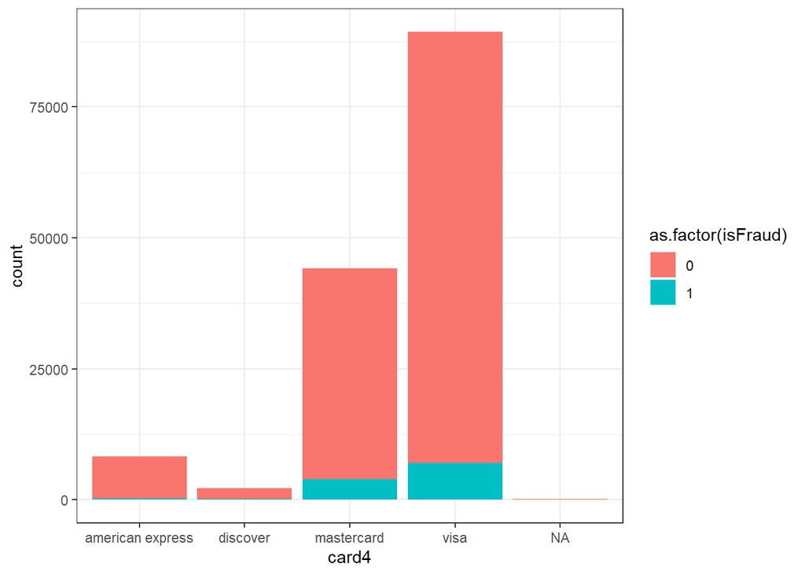

```r
#Card4
ggplot(train_raw, aes(x=card4,fill=as.factor(isFraud))) + geom_bar() + theme_bw()
```

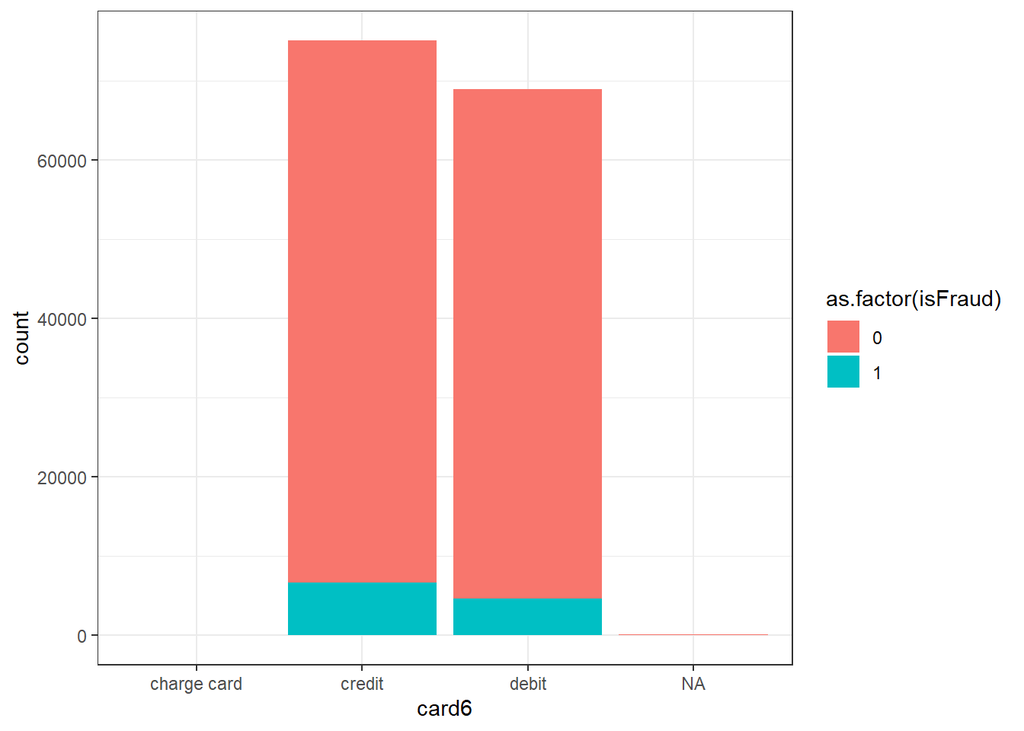

```r
#Card6
ggplot(train_raw, aes(x=card6,fill=as.factor(isFraud))) + geom_bar() + theme_bw()
```

En las gráficas se puede ver como a priori estas variables apenas tienen relevancia en cuanto a si una transacción es fraudulenta o no. Aunque se puede ver como en el caso de la compañía de la tarjeta “visa” tiene más casos de fraude que “mastercard” se puede ver como la primera tiene una presencia en el dataset mucho mayor por lo que tiene sentido que haya más casos de fraude que en la segunda. Algo similar ocurre con el tipo de la tarjeta, ya que charge “credit” y “debit” tienen prácticamente la misma proporción de fraude.

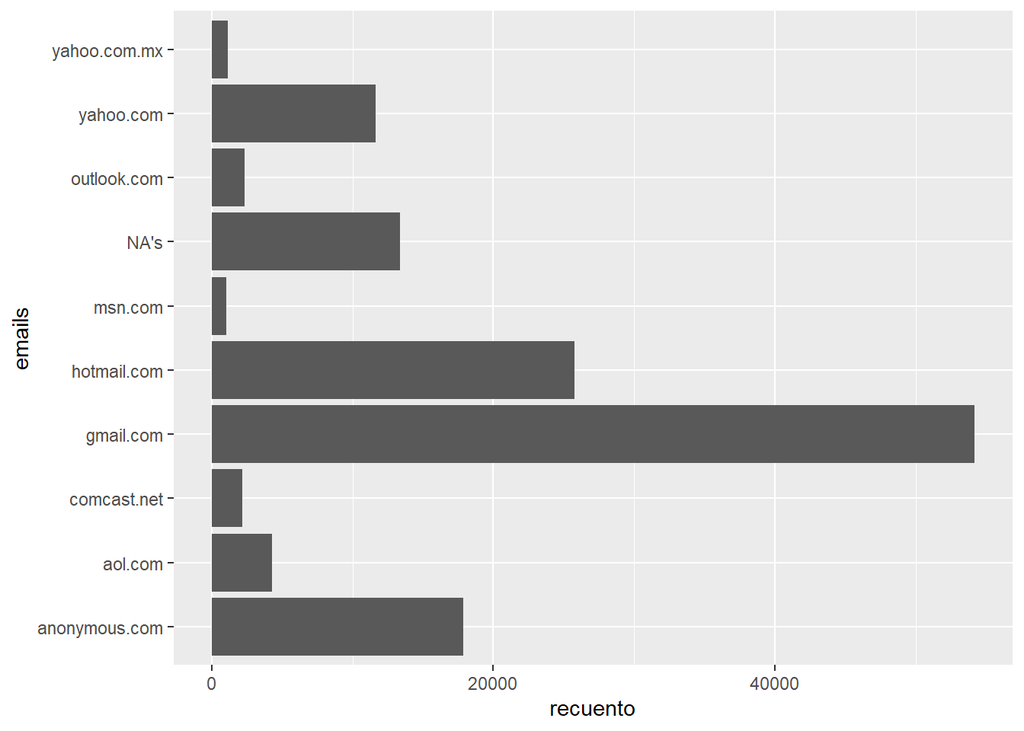

```r
#P_emaildomain
# Extraemos un resumen acerca de los emails.
recuento_emails<-summary(train_raw$P_emaildomain)
# Convertimos los resultados anteriores en una matriz para poder trabajar con ellos.
emails_matriz<-data.matrix(recuento_emails)
# Obtenemos los nombres.
emails<-names(recuento_emails)
# También obtenemos el número de muestras de cada email
recuento<-emails_matriz[1:length(emails_matriz)]
# Componemos un data frame con los emails y las ocurrencias de cada dominio
dataframe<-data.frame(emails=emails, recuento=recuento)
dataframe <- dataframe[order(dataframe$recuento, decreasing = TRUE),]
dataframe <- head(dataframe, 10)

#Las dibujamos
ggplot(data=dataframe, aes(x=emails, y=recuento)) + geom_bar(stat="identity")+coord_flip()
```

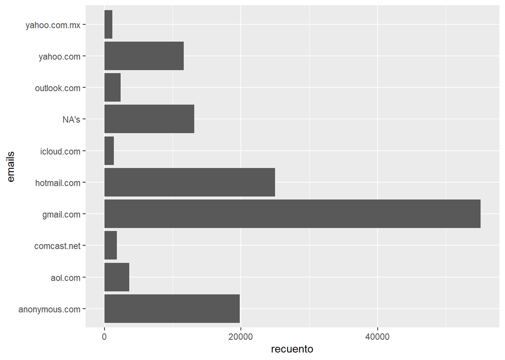

```r
#R_emaildomain
# Extraemos un resumen acerca de los emails.
recuento_emails<-summary(train_raw$R_emaildomain)
# Convertimos los resultados anteriores en una matriz para poder trabajar con ellos.
emails_matriz<-data.matrix(recuento_emails)
# Obtenemos los nombres.
emails<-names(recuento_emails)
# También obtenemos el número de muestras de cada email
recuento<-emails_matriz[1:length(emails_matriz)]
# Componemos un data frame con los emails y las ocurrencias de cada dominio
dataframe<-data.frame(emails=emails, recuento=recuento)
dataframe <- dataframe[order(dataframe$recuento, decreasing = TRUE),]
dataframe <- head(dataframe, 10)

ggplot(data=dataframe, aes(x=emails, y=recuento)) + geom_bar(stat="identity")+coord_flip()
```

```r
rm(dataframe, emails_matriz, emails, recuento_emails, recuento)
```

Como podemos ver, los dominios están bastante distribuidos pero hay que destacar que como era de esperar gmail es el predominante.

# Pre-procesamiento

Una vez que nos hemos hecho una idea de la forma general que tiene nuestro dataset, podemos pasar a preprocesar los datos. Por lo tanto en este apartado transformaremos nuestro dataset para poder optimizarlo en la resolución de nuestro problema.

```r
status <- df_status(train_raw)
```

```r
#Excluimos "isFraud"
status <- status %>%
  filter(variable != 'isFraud')

#Identificamos columnas con mas del 90% de 0
zero_cols <- status %>%
  filter(p_zeros > 90) %>%
  select(variable)

#identificamos columnas con más del 50% de na
na_cols <- status %>%
  filter(p_na > 50) %>%
  select(variable)

#identificamos columnas con menos de 3 valores diferentes

eq_cols <- status %>%
  filter(unique <= 3) %>%
  select(variable)

#Eliminamos columnas
remove_cols <- bind_rows(
  list(
    zero_cols,
    na_cols,
    eq_cols
  )
)

data <- train_raw %>%
  select(-one_of(remove_cols$variable))

paste('Se han eliminado', ncol(train_raw) - ncol(data), 'columnas de', ncol(train_raw))
```

```
## [1] "Se han eliminado 182 columnas de 434"
```

Una vez eliminadas las filas pasamos a estudiar la correlación entre las distintas variables de nuestro dataset y nuestra variable objetivo. Para ello primero habrá que convertir las variables categóricas en numéricas y excluir los valores vacíos o perdidos.

```r
data_num <- data %>%
  #Eliminamos filas con na
  na.exclude() %>%
  #Convertimos todas las variables no numericas a numéricas
  mutate_if(is.character, as.factor) %>%
  mutate_if(is.factor, as.numeric)

#Calculamos la correlación de las variables con "isFraud" y guardamos las variables mas correladas
cor_target <- correlation_table(data_num, target='isFraud')
important_vars <- cor_target %>%
  filter(abs(isFraud) >= 0.2)

#Guardamos solo las variables más correladas
data_clean <- data %>%
  select(one_of(important_vars$Variable))

testID = test_raw$TransactionID
test_clean <- test_raw %>%
  select(one_of(important_vars$Variable))
test_clean$TransactionID = testID
rm(data_num)
```

Ya que la clase “isFraud” está tremendamente desbalanceada, vamos a realizar un “undersampling” de la clase mayoritaria, es decir vamos a seleccionar un número menor de filas con “isFraud” igual a 0. De esta forma ademas de mejorar los tiempos de ejecución haremos que la clasificación se realice mejor. Aun así probaremos a realizar la clasificación con undersampling y sin under sampling para comparar los resultados[6]. Ademas de lo comentado anteriormente, antes de realizar el modelo de predicción se van a eliminar las filas que contengan algún valor perdido y es que aunque no sea el mejor modo de tratar los valores perdidos por motivos de tiempo se realizara este método.

```r
data_clean$isFraud = as.factor(data_clean$isFraud)
data_clean <- data_clean %>%
  na.exclude()
cat("Total de filas por clase isFraud antes de hacer under sampling")
```

```
## Total de filas por clase isFraud antes de hacer under sampling
```

```r
table(data_clean$isFraud)
```

```
##
##     0     1
## 73202  3490
```

```r
#under sampling
predictors <- select(data_clean, -isFraud)
data_down <- downSample(x = predictors, y = data_clean$isFraud, yname = 'isFraud')
cat("\nTotal de filas por clase isFraud despues de hacer under sampling")
```

```
##
## Total de filas por clase isFraud despues de hacer under sampling
```

```r
table(data_down$isFraud)
```

```
##
##    0    1
## 3490 3490
```

Una vez modificados los datasets pasamos a crear el modelo de clasificación a partir de ellos.

# Clasificación

```r
#Primero convertimos las clases de valores numericos a texto para prevenir errores más adelante
data_clean$isFraud = mapvalues(data_clean$isFraud, from = c("0", "1"), to = c("NotFraud", "Fraud"))
data_down$isFraud = mapvalues(data_down$isFraud, from = c("0", "1"), to = c("NotFraud", "Fraud"))

set.seed(0)
trainIndex <- createDataPartition(data_clean$isFraud, p = .7, list = FALSE)
train_clean <- data_clean[trainIndex, ]
val_clean   <- data_clean[-trainIndex, ]

trainIndex <- createDataPartition(data_down$isFraud, p = .7, list = FALSE)
train_down <- data_down[trainIndex, ]
val_down   <- data_down[-trainIndex, ]
```

Una vez creados los conjuntos de datos necesarios pasamos al entrenamiento del primer modelo. Este es Random forest.

```r
#Configuración del modelo
rfCtrl <- trainControl(
      verboseIter = F,
      classProbs = TRUE,
      method = "repeatedcv",
      number = 10,
      repeats = 1,
      summaryFunction = twoClassSummary)
#Configuracion módelo sin under sampling
rfParametersGrid <- expand.grid(
      .mtry = c(sqrt(ncol(train_clean))))

#Entrenamiento modelo sin under sampling
rfModel <- train(
    isFraud ~ .,
    data = train_clean,
    method = "rf",
    metric = "Accuracy",
    trControl = rfCtrl,
    tuneGrid = rfParametersGrid)
#Configuracion módelo con under sampling
mini_rfParametersGrid <- expand.grid(
      .mtry = c(sqrt(ncol(train_down))))

#Entrenamiento módelo con under sampling
mini_rfModel <- train(
    isFraud ~ .,
    data = train_down,
    method = "rf",
    metric = "Accuracy",
    trControl = rfCtrl,
    tuneGrid = mini_rfParametersGrid)
prediction <- predict(rfModel, val_clean, type = "raw")
cm_train <- confusionMatrix(prediction, val_clean$isFraud)

mini_prediction <- predict(mini_rfModel, val_down, type = "raw")
mini_cm_train <- confusionMatrix(mini_prediction, val_down$isFraud)

cat("Resultados modelo sin under sampling\n")
```

```
## Resultados modelo sin under sampling
```

```r
cm_train
```

```
## Confusion Matrix and Statistics
##
##           Reference
## Prediction NotFraud Fraud
##   NotFraud    21904   604
##   Fraud          56   443
##
##                Accuracy : 0.9713
##                  95% CI : (0.9691, 0.9734)
##     No Information Rate : 0.9545
##     P-Value [Acc > NIR] : < 2.2e-16
##
##                   Kappa : 0.5602
##
##  Mcnemar's Test P-Value : < 2.2e-16
##
##             Sensitivity : 0.9974
##             Specificity : 0.4231
##          Pos Pred Value : 0.9732
##          Neg Pred Value : 0.8878
##              Prevalence : 0.9545
##          Detection Rate : 0.9521
##    Detection Prevalence : 0.9783
##       Balanced Accuracy : 0.7103
##
##        'Positive' Class : NotFraud
##
```

```r
cat("\n\n Resultados modelo con under sampling\n")
```

```
##
##
##  Resultados modelo con under sampling
```

```r
mini_cm_train
```

```
## Confusion Matrix and Statistics
##
##           Reference
## Prediction NotFraud Fraud
##   NotFraud      919   379
##   Fraud         128   668
##
##                Accuracy : 0.7579
##                  95% CI : (0.7389, 0.7761)
##     No Information Rate : 0.5
##     P-Value [Acc > NIR] : < 2.2e-16
##
##                   Kappa : 0.5158
##
##  Mcnemar's Test P-Value : < 2.2e-16
##
##             Sensitivity : 0.8777
##             Specificity : 0.6380
##          Pos Pred Value : 0.7080
##          Neg Pred Value : 0.8392
##              Prevalence : 0.5000
##          Detection Rate : 0.4389
##    Detection Prevalence : 0.6199
##       Balanced Accuracy : 0.7579
##
##        'Positive' Class : NotFraud
##
```

Como se puede ver, el mejor modelo es el que no utiliza under sampling con una precisión 0.97 sobre el conjunto de validación contra un 0.76. Esto tiene mucho sentido, ya que en el caso de utilizar esta técnica eliminamos muchos de los datos y perdemos una gran cantidad de información. Esto no quiere decir que esta técnica no sea útil, sino que en este caso y debido al gran desbalanceo entre las clases a predecir no es útil, en un dataset con un menor desbalanceo puede llegar a ser útil.

Una vez realizado el primer modelo con random forest vamos a complementarlo con otro algoritmo de clasificación. Este será el particionado recursivo. Como se verá en el siguiente bloque de código el proceso de configuración será similar al del modelo anterior.

```r
#Configuracion módelo
rpartParametersGrid <- expand.grid(.cp = c(0.01, 0.05))

#Entrenamiento modelo sin under sampling
rpartModel <- train(
    isFraud ~ .,
    data = train_clean,
    method = "rpart",
    metric = "Accuracy",
    trControl = rfCtrl,
    tuneGrid = rpartParametersGrid)
#Entrenamiento módelo con under sampling
mini_rpartModel <- train(
    isFraud ~ .,
    data = train_down,
    method = "rpart",
    metric = "Accuracy",
    trControl = rfCtrl,
    tuneGrid = rpartParametersGrid)
prediction_rpart <- predict(rpartModel, val_clean, type = "raw")
cm_train_rpart <- confusionMatrix(prediction_rpart, val_clean$isFraud)

mini_prediction_rpart <- predict(mini_rpartModel, val_down, type = "raw")
mini_cm_train_rpart <- confusionMatrix(mini_prediction_rpart, val_down$isFraud)

cat("Resultados modelo sin under sampling\n")
```

```
## Resultados modelo sin under sampling
```

```r
cm_train_rpart
```

```
## Confusion Matrix and Statistics
##
##           Reference
## Prediction NotFraud Fraud
##   NotFraud    21830   700
##   Fraud         130   347
##
##                Accuracy : 0.9639
##                  95% CI : (0.9614, 0.9663)
##     No Information Rate : 0.9545
##     P-Value [Acc > NIR] : 6.68e-13
##
##                   Kappa : 0.4394
##
##  Mcnemar's Test P-Value : < 2.2e-16
##
##             Sensitivity : 0.9941
##             Specificity : 0.3314
##          Pos Pred Value : 0.9689
##          Neg Pred Value : 0.7275
##              Prevalence : 0.9545
##          Detection Rate : 0.9488
##    Detection Prevalence : 0.9793
##       Balanced Accuracy : 0.6628
##
##        'Positive' Class : NotFraud
##
```

```r
cat("\n\n Resultados modelo con under sampling\n")
```

```
##
##
##  Resultados modelo con under sampling
```

```r
mini_cm_train_rpart
```

```
## Confusion Matrix and Statistics
##
##           Reference
## Prediction NotFraud Fraud
##   NotFraud      816   344
##   Fraud         231   703
##
##                Accuracy : 0.7254
##                  95% CI : (0.7057, 0.7444)
##     No Information Rate : 0.5
##     P-Value [Acc > NIR] : < 2.2e-16
##
##                   Kappa : 0.4508
##
##  Mcnemar's Test P-Value : 3.001e-06
##
##             Sensitivity : 0.7794
##             Specificity : 0.6714
##          Pos Pred Value : 0.7034
##          Neg Pred Value : 0.7527
##              Prevalence : 0.5000
##          Detection Rate : 0.3897
##    Detection Prevalence : 0.5540
##       Balanced Accuracy : 0.7254
##
##        'Positive' Class : NotFraud
##
```

En este segundo modelo obtenemos unos resultados bastante parecidos en cuanto al conjunto con y sin under sampling. El motivo es el mismo que el especificado anteriormente, la perdida de información al reducir tanto el conjunto de entrenamiento. Los valores de precisión son de 0.96 y de 0.73 que aunque algo peor que en el caso anterior utilizando random forest cabe destacar que la eficiencia a nivel de tiempo de computo es tremenda, tardando este último modelo menos de un minuto mientras que el anterior tardaba cerca de 2 horas.

## Discusión de resultados

Como se ha podido ver en el apartado anterior los resultados obtenidos son bastante esperanzadores, habiendo obtenido 0.97 como precisión en el mejor modelo, un resultado bastante aceptable. Sin embargo cabe destacar, como se ha comentado, la rapidez de ejecución de un algoritmo frente al otro, que aunque se pierda cerca de 0.01 de precisión de un modelo con respecto al otro, la ganancia en términos de coste computacional es tremenda. Por otro lado, como se ha podido ver el resultado de la ejecución con under sampling no ha dado sus frutos. Aunque era de esperar que al reducir el desbalanceo de las clases se pudiese mejorar el resultado al prevenir el sobreaprendizaje de una clase con respecto a la otra, se ha visto que al reducir tanto el dataset el modelo no es capaz de generalizar correctamente y de “aprender” a diferenciar una clase de otra. Por lo tanto esta técnica no nos es útil en nuestro propósito.

# Conclusiones

Como se ha visto a lo largo de esta práctica es muy complejo interpretar los datos de los que a veces se dispone y es que aunque es de esperar que por ejemplo el fraude este muy relacionado con la cantidad de dinero de la transacción hemos visto que no es así, y aunque está relacionado, dicha relación no es lo suficientemente representativa. Por otro lado, hemos visto como hay varios datos en nuestro dataset que se encuentran tremendamente relacionados con el hecho de que la transacción sea fraudulenta o no. Sin embargo, dichos datos no son fácilmente interpretables y es que no se ofrece una descripción de su significado, aunque es de esperar que estos sean variables calculadas previamente a partir del resto de variables.

Esto nos hace pensar que en la mayor parte de los casos, no nos basta con aplicar uno u otro método de predicción sobre los datos que tenemos sino que habrá ocasiones en las que deberemos pararnos y calcular nuevos datos sobre los disponibles. Obteniendo así mejores datos con los que realizar nuestro modelo.

Ademas de esto se ha visto la técnica del under sampling que como se ha comentado no nos ha sido de utilidad, ya que debido al desbalanceo en la clase objetivo se pierde demasiada información al realizar dicha técnica. Cosa que nos muestra que a veces es mejor trabajar con muchos datos poco balanceados que con muy pocos y muy balanceados.

# Bibliografía

1. *Kaggle* https://www.kaggle.com
2. *IEEE-CIS Fraud Detection Competition* https://www.kaggle.com/c/ieee-fraud-detection/data
3. *IEEE extensive EDA & LGB with R* https://www.kaggle.com/psystat/ieee-extensive-eda-lgb-with-r
4. Oscar Ramírez-Alán, *Correlación y Regresión Lineal*, https://rpubs.com/osoramirez/316691
5. Juan Gomez Romero, *Apuntes de clase de SIGE*, https://github.com/jgromero/sige2020/tree/master/Pr%C3%A1cticas
6. *Practical Guide to deal with Imbalanced Classification Problems in R*, https://www.analyticsvidhya.com/blog/2016/03/practical-guide-deal-imbalanced-classification-problems/
7. *The caret Package / Random forest* http://topepo.github.io/caret/train-models-by-tag.html#random-forest